# ChIP-seq data analysis

## 3.3 Over-representation analysis

There are a plethora of functional enrichment tools that perform some type of over-representation analysis by querying databases containing information about gene function and interactions. Querying these databases for gene function requires the use of a consistent vocabulary to describe gene function. One of the **most widely-used vocabularies is the Gene Ontology (GO)**. This vocabulary was established by the Gene Ontology project, and the words in the vocabulary are referred to as GO terms.

We will be using [`clusterProfiler`](http://bioconductor.org/packages/release/bioc/html/clusterProfiler.html) to perform over-representation analysis on GO terms associated with our list of significant genes. The tool takes as input a significant gene list and a background gene list and performs statistical enrichment analysis using hypergeometric testing. The basic arguments allow the user to select the appropriate organism and GO ontology (BP, CC, MF) to test.

Let’s start with our gene list from **Nanog annotations** and use them as input for a **GO enrichment analysis of biological process terms**.

```r
# Run GO enrichment analysis
ego <- enrichGO(gene = entrez,
                    keyType = "ENTREZID",
                    OrgDb = org.Hs.eg.db,
                    ont = "BP",
                    pAdjustMethod = "BH",
                    qvalueCutoff = 0.05,
                    readable = TRUE)
```

The `ego` object we created contains the results of the over-representation analysis. We can extract it into a data frame and **write the results to file**:

```r
# Output results from GO analysis to a table
cluster_summary <- data.frame(ego)

# Print top 10 terms
cluster_summary[1:10, c(1, 2, 3, 8)]
```

```
##                    ID                          Description GeneRatio
## GO:0034329 GO:0034329               cell junction assembly  140/3020
## GO:0050808 GO:0050808                 synapse organization  137/3020
## GO:0007409 GO:0007409                         axonogenesis  145/3020
## GO:0030900 GO:0030900                forebrain development  124/3020
## GO:0022604 GO:0022604     regulation of cell morphogenesis  146/3020
## GO:0043087 GO:0043087        regulation of GTPase activity  140/3020
## GO:0007416 GO:0007416                     synapse assembly   70/3020
## GO:0007411 GO:0007411                        axon guidance   94/3020
## GO:0097485 GO:0097485           neuron projection guidance   94/3020
## GO:1901888 GO:1901888 regulation of cell junction assembly   73/3020
##                                                                                                                                                                                                                                                                                                          …
## GO:0034329                                                                               LRFN5/CNTN5/GPC4/MEF2C/CLDN1/CTNND2/EPHA7/NTN1/GRID2/THBS1/E…
## GO:0050808                                                                                           LRFN5/CNTN5/ARHGAP22/GPC4/MEF2C/CTNND2/EPHA7/EPHA4/NTN1/ABI2…
## GO:0007409                                                          SEMA3A/AUTS2/NRXN3/DOK5/COBL/EPHA7/SLIT2/EPHA4/NTN1/USP9X/BC…
## GO:0030900                                                                                                                                                                                                     SEMA3A/NPY/KDM2B/NEUROD6/DCLK2/TBX3/SLIT2/BCL11B/NRP2/EZH2/R…
## GO:0022604                               SEMA3A/KANK1/EPHA7/SLIT2/EPHA4/DIAPH1/NTN1/ABI2/SEMA3E/ACTR2…
## GO:0043087 DENND1A/ARHGAP11A/RGS3/ARHGAP22/GIT1/ARHGAP27/SLIT2/EPHA4/ER…
## GO:0007416                                                                                                                                                                                                                                                                                               …
## GO:0007411                                                                                                                                                                                                                                                                                               …
## GO:0097485                                                                                                                                                                                                                                                                                               …
## GO:1901888                                                                                                                                                                                                                                                                                               …
```

```r
# We can save the results to a csv table
dir.create('results')
write.csv(cluster_summary, "results/clusterProfiler_Nanog.csv")
```

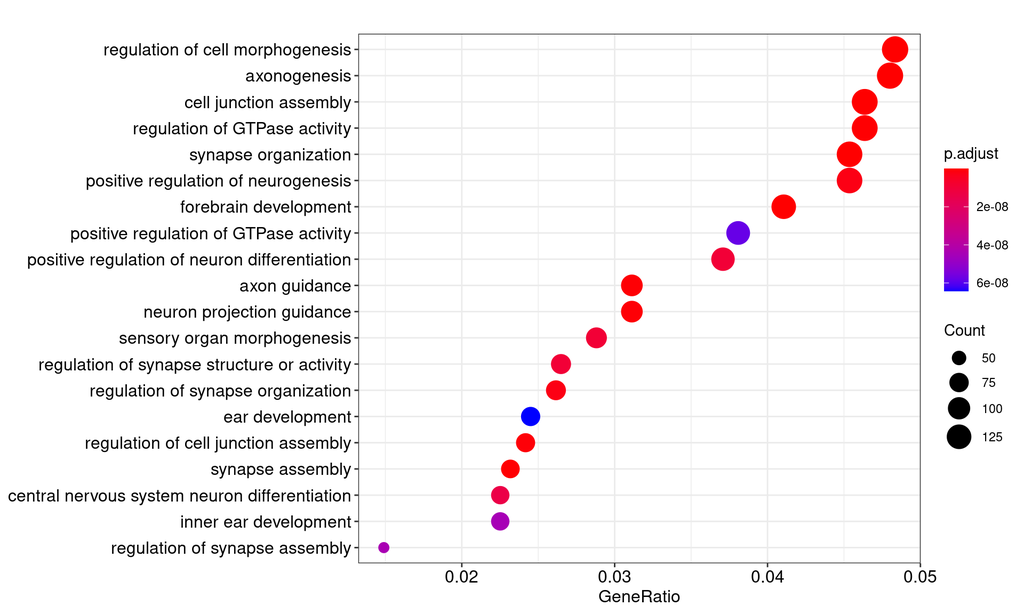

```r
# Dotplot visualization

dotplot(ego, showCategory = 20)
```

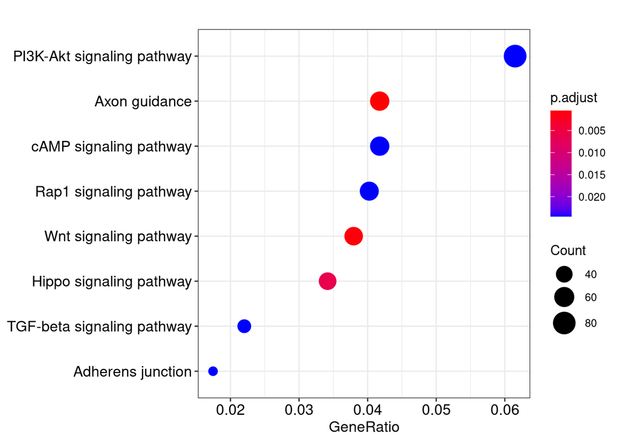

```r
ekegg <- enrichKEGG(gene = entrez,
                 organism = 'hsa',
                 pvalueCutoff = 0.05)

dotplot(ekegg)
```

## 3.4 Comparing enrichment across samples

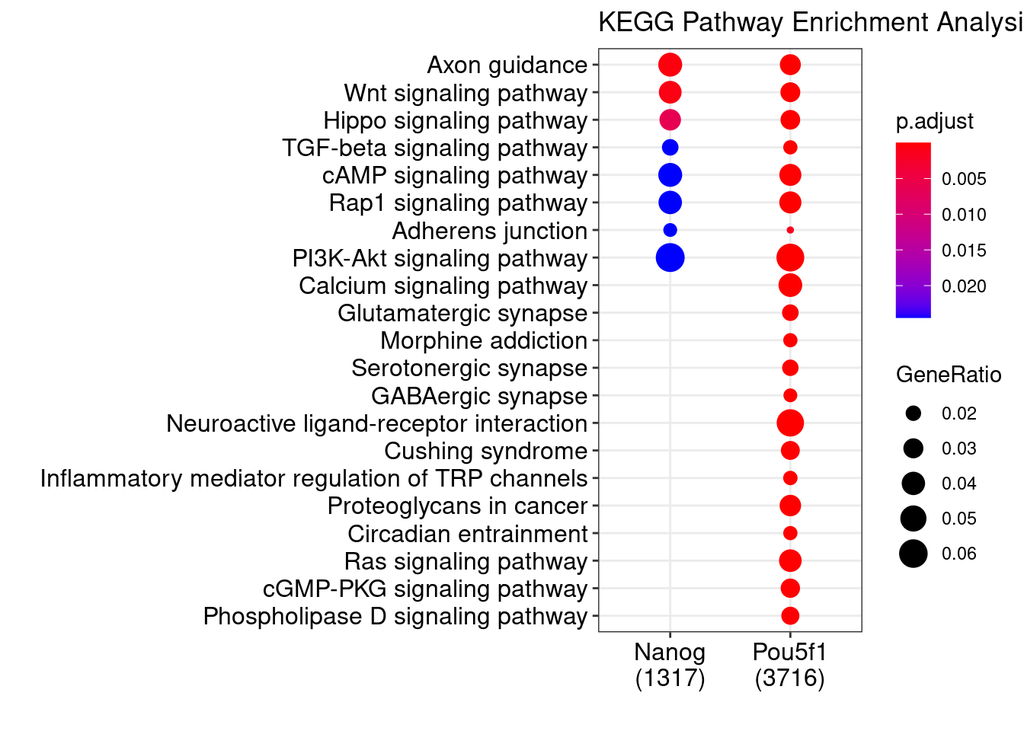

```r
# Create a list with genes from each sample
genes = lapply(peakAnnoList, function(i)
  as.data.frame(i)$geneId)

# Run KEGG analysis
compKEGG <- compareCluster(
  geneCluster = genes,
  fun = "enrichKEGG",
  organism = "human",
  pvalueCutoff  = 0.05,
  pAdjustMethod = "BH"
)

dotplot(compKEGG, showCategory = 20, title = "KEGG Pathway Enrichment Analysis")
```

# 4 Functional enrichment: Web-based tools

In the previous steps, we generated NANOG sequences file at ‘results/nanog_top250.fasta’, we can use web-based tool for enrichment analysis on genomic regions and peak sequences.

**a popular one is [GREAT](http://great.stanford.edu/public/html/)** (Genomic Regions Enrichment of Annotations Tool). GREAT is used to analyze the functional significance of cis-regulatory regions identified by localized measurements of DNA binding events across an entire genome[1](http://bejerano.stanford.edu/papers/GREAT.pdf). It **incorporates annotations from 20 different ontologies** and is an easy to use tool which generates annotation and downstream functional enrichement results for genomic coordinate files. The utility of GREAT is not limited to ChIP-seq, as it could also be applied to open chromatin, localized epigenomic markers and similar functional data sets, as well as comparative genomics sets.

In the interest of time we will not go into the details of using GREAT, however we have [materials linked here](https://hbctraining.github.io/Intro-to-ChIPseq/lessons/web_based_functional_analysis.html) if you are interested in testing it out with this dataset. There also [demo datasets](http://great.stanford.edu/public/html/demo.php) on the GREAT website that you can use to test out the functionality of the tool.

## 4.1 Motif discovery

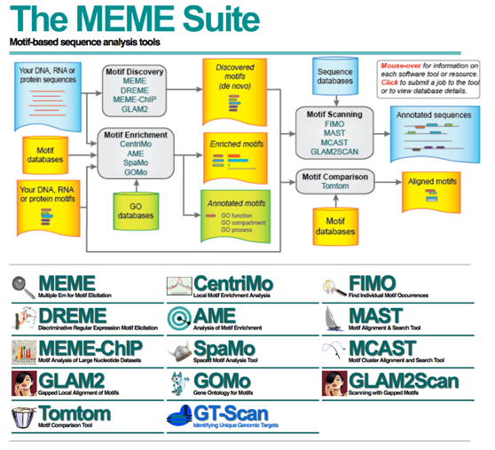

We upload the NANOG peak sequences to MEME, here we set the maximum motif length to 12 bps rather than the default 50 bps.

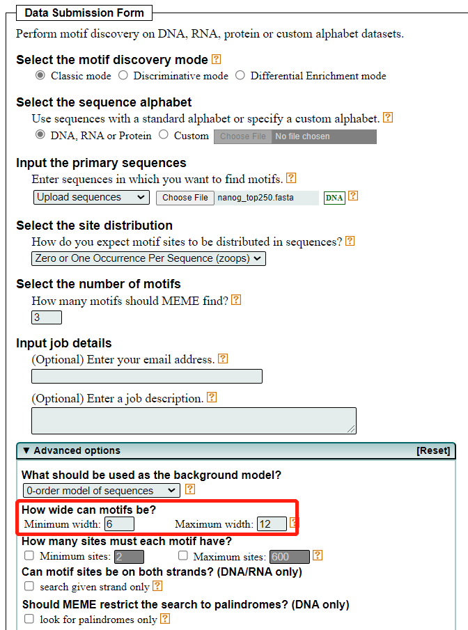

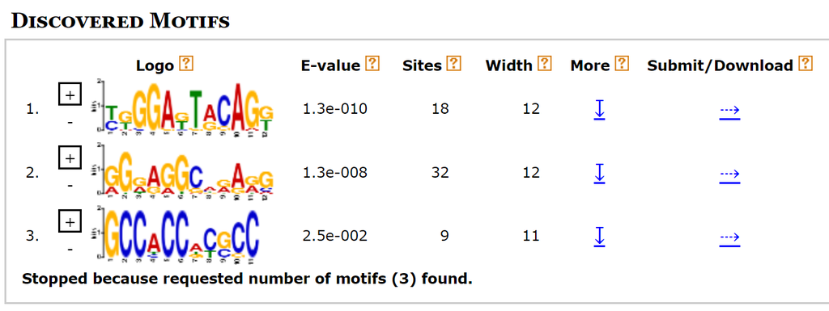

## 4.2 Tomtom

To determine if the identified motifs resemble the binding motifs of known transcription factors, we can submit the motifs to Tomtom, which searches a database of known motifs to find potential matches and provides a statistical measure of motif-motif similarity. We can run the analysis individually for each motif prediction by performing the following steps:

1. Click on the `Submit / Download` button for motif in the MEME output
2. A dialog box will appear asking you to Select what you want to do or Select a program. Select `Tomtom` and click `Submit`. This takes you to the input page.
3. Tomtom allows you to select the database you wish to search against. Keep the default parameters selected, but keep in mind that there are other options when performing your own analyses.
4. Enter your email address and job description and start the search.

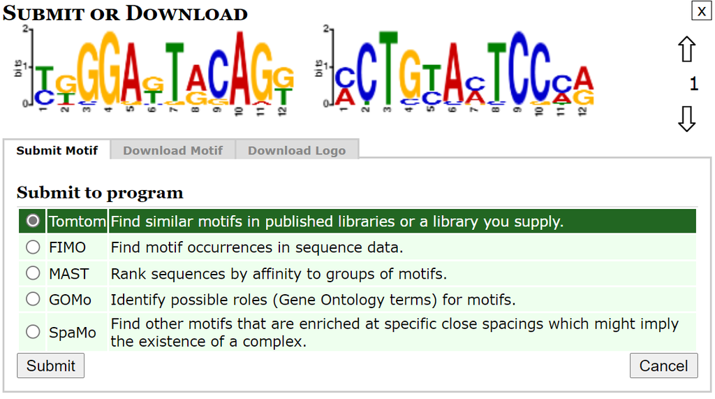

You will be shown a status page describing the inputs and the selected parameters, as well as a link to the results at the top of the screen. Clicking the link displays an output page that is continually updated until the analysis has completed. Like MEME, Tomtom will also email you the results.

**Note: We use HOCOMOCO v11 motif database here**

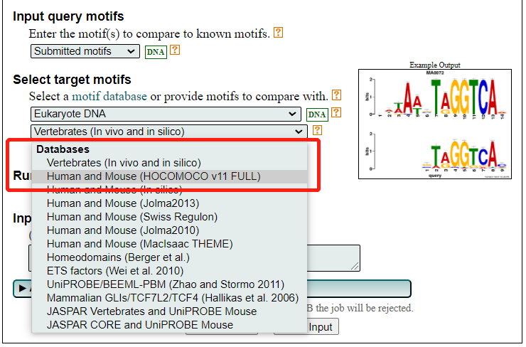

The HTML output for Tomtom shows a list of possible motif matches for the MEME motif prediction generated from your Nanog regions. Clicking on the match name shows you an alignment of the predicted motif versus the match.

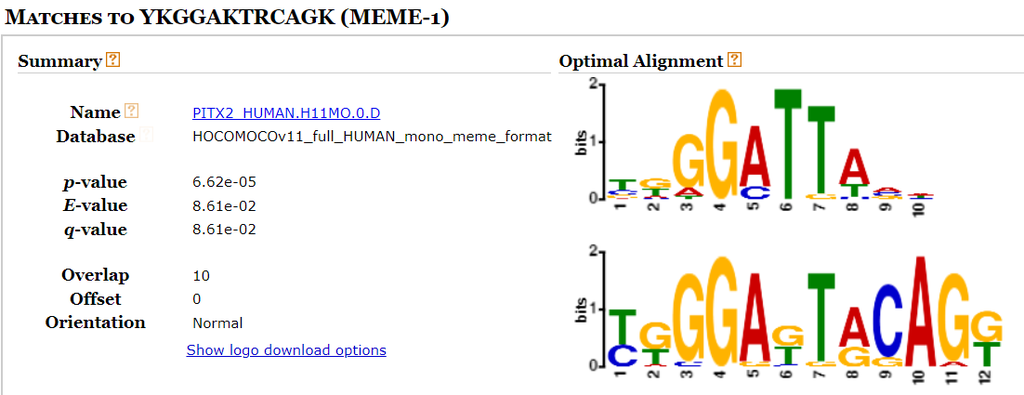

If we compare our results with what is known about our transcription factor, Nanog, we find that Sox2 and Pou5f1 (Oct4) co-regulate many of the same genes as Nanog.

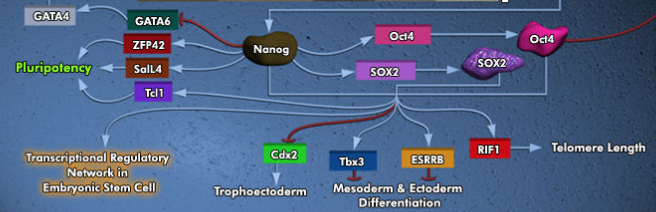

https://www.qiagen.com/us/shop/genes-and-pathways/pathway-details/?pwid=309

## 4.3 MEME-ChIP

MEME-ChIP is a tool that is part of the MEME Suite that is specifically designed for ChIP-seq analyses. MEME-ChIP performs MEME and Tomtom analysis in addition to using tools to assess which motifs are most centrally enriched (motifs should be centered in the peaks) and to combine related motifs into similarity clusters. It is able to identify longer motifs < 30bp, but takes much longer to run.

The MEME-ChIP website is available [here](https://meme-suite.org/meme/tools/meme-chip).

[figure not shown]

*The lesson material has been developed by members of the BMBL.*